# IODS course project

## Step 5

### Checking the assumptions of the model

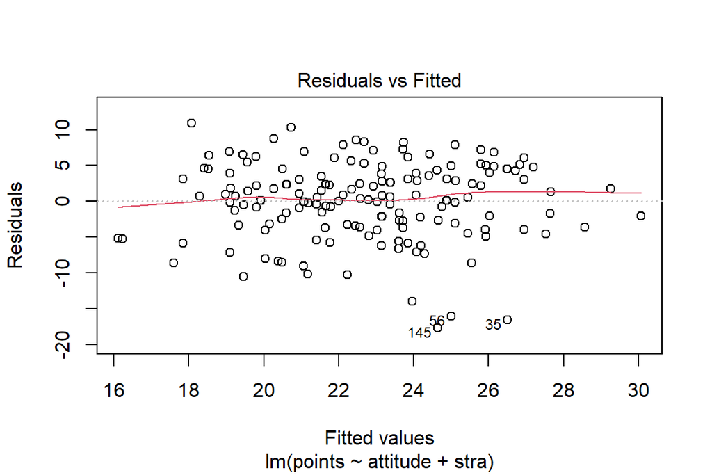

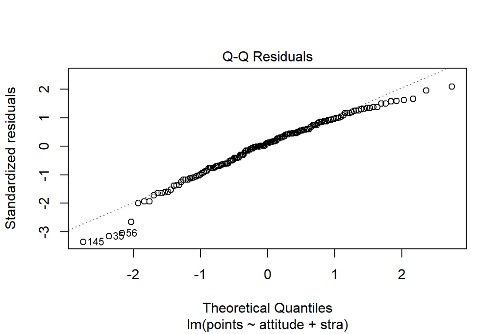

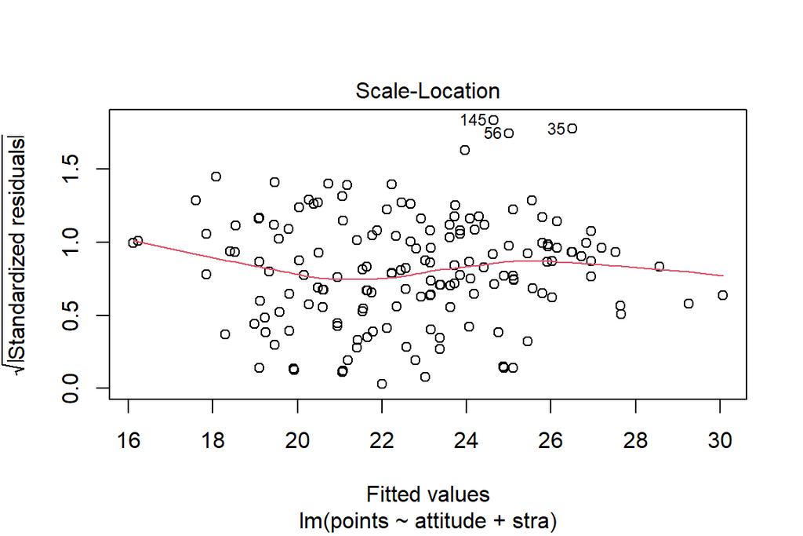

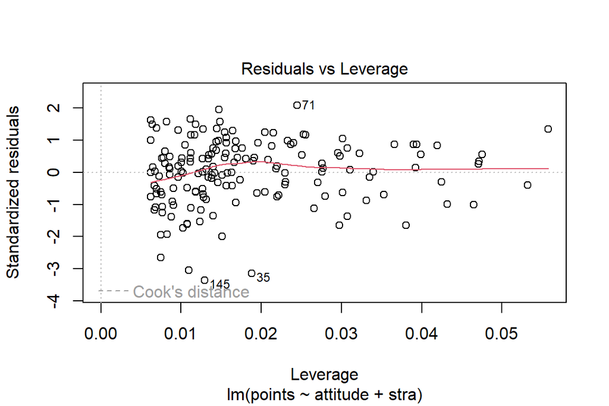

```r
plot(final_model)
```

#### The assumptions of linear regression model:

First, linear regression needs the relationship between the independent and dependent variables to be linear. Secondly, the linear regression analysis requires all variables to be multivariate normal. Thirdly, linear regression assumes that there is little or no multicollinearity in the data. Fourth, linear regression analysis requires that there is little or no autocorrelation in the data.

#### Checking the model validation:

From the residuals vs Fitted value, we can not see clear skewness, so we can say that fitted values have been distributed throughout the plot.

# Chapter 3: Logistic regression analysis

## Step 2

```r
alc_data <- read.csv("data/alc.csv")

library(tidyverse)
glimpse(alc_data)
```

```
## Rows: 370
## Columns: 35
## $ school     <chr> "GP", "GP", "GP", "GP", "GP", "GP", "GP", "GP", "GP", "GP",…
## $ sex        <chr> "F", "F", "F", "F", "F", "M", "M", "F", "M", "M", "F", "F",…
## $ age        <int> 18, 17, 15, 15, 16, 16, 16, 17, 15, 15, 15, 15, 15, 15, 15,…
## $ address    <chr> "U", "U", "U", "U", "U", "U", "U", "U", "U", "U", "U", "U",…
## $ famsize    <chr> "GT3", "GT3", "LE3", "GT3", "GT3", "LE3", "LE3", "GT3", "LE…
## $ Pstatus    <chr> "A", "T", "T", "T", "T", "T", "T", "A", "A", "T", "T", "T",…
## $ Medu       <int> 4, 1, 1, 4, 3, 4, 2, 4, 3, 3, 4, 2, 4, 4, 2, 4, 4, 3, 3, 4,…
## $ Fedu       <int> 4, 1, 1, 2, 3, 3, 2, 4, 2, 4, 4, 1, 4, 3, 2, 4, 4, 3, 2, 3,…
## $ Mjob       <chr> "at_home", "at_home", "at_home", "health", "other", "servic…
## $ Fjob       <chr> "teacher", "other", "other", "services", "other", "other", …
## $ reason     <chr> "course", "course", "other", "home", "home", "reputation", …
## $ guardian   <chr> "mother", "father", "mother", "mother", "father", "mother",…
## $ traveltime <int> 2, 1, 1, 1, 1, 1, 1, 2, 1, 1, 1, 3, 1, 2, 1, 1, 1, 3, 1, 1,…
```

[output cut: 22 more lines]

In this data set, there are 370 observations ans 35 variables. The data is about prediction of students grade in two distinct subjects such as Mathematics and Portuguese language at the final year of secondary education. The three academic year have been referred by G1, G2 and G3. The data also contain demographic, social and school related features through measuring various related variables.

## Step 3

```r
# access the tidyverse libraries tidyr, dplyr, ggplot2
library(tidyr)
library(dplyr)
library(ggplot2)

# glimpse at the alc data


#Producing summary statistics by group
alc_data %>% group_by(high_use) %>% summarise(count = n())
```

```
## # A tibble: 2 × 2
##   high_use count
##   <lgl>    <int>
## 1 FALSE      259
## 2 TRUE       111
```

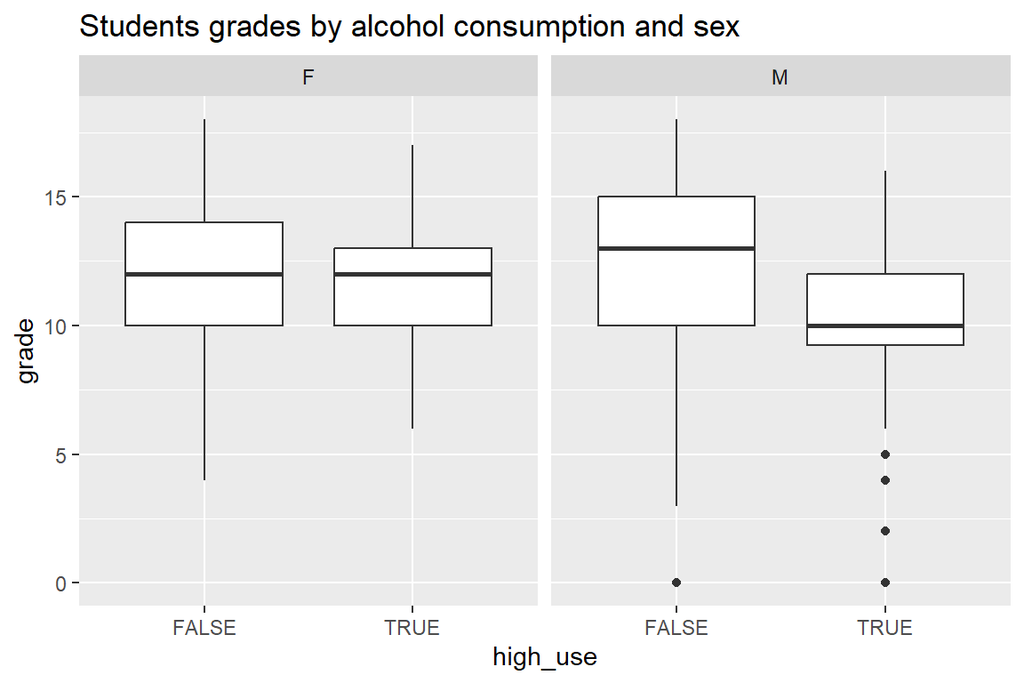

```r
# initialize a plot of high_use and G3
g1 <- ggplot(alc_data, aes(x = high_use, y = G3))

# define the plot as a boxplot and draw it
g1 + geom_boxplot() + ylab("grade")+facet_wrap(~sex)+
  ggtitle("Students grades by alcohol consumption and sex")
```

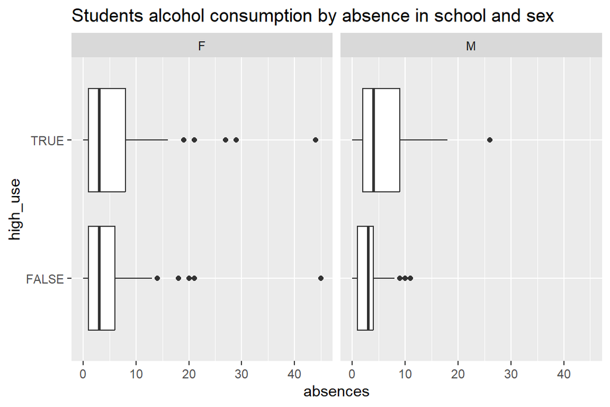

```r
# initialize a plot of high_use and absences

g2 <- ggplot(alc_data, aes(x = absences, y = high_use))
g2+geom_boxplot()+facet_wrap(~ sex) + ggtitle("Students alcohol consumption by absence in school and sex")
```

From this boxplot we can say female students absence do not vary alcohol consumption but in case of male it varies.